# Seasonal Agriculture Performance Analysis

## Major Data Analysis Project: VOIS - AICTE Internship 2026

- **Domain:** Agriculture
- **Theme:** Seasonal Agriculture Performace
- **Tools:** Python (Jupyter Notebook environment), Pandas, NumPy, Matplotlib, Seaborn
- **Prepared by:** SANTHOSHA J
- **STU ID:** STU6903150a9baac1761809674
- **Internship ID:** INTERNSHIP_17830691666a4779eecfe8a

**Project Goal:** To analyse agricultural performance across different seasons using the given dataset, identify key patterns, trends, and variations, and derive data-driven insights to support better seasonal agricultural planning.

## 1. Problem Statement:

Agricultural activities are influenced by seasonal variations in environmental conditions, farming practices, resource availability and market conditions. As a result, agricultural performance may differ from one season to another.

However, raw agricultural data do not clearly explain how agricultural performance changes across seasons or what patterns can be observed in different seasonal conditions.

The given dataset needs to be analysed to identify seasonal patterns, trends, relationships, and variations in agricultural performance and understand how these differences can support better agricultural planning.

## 2. Project Objectives:

- Explore and understand the agricultural dataset.
- Clean and prepare the data for analysis.
- Analyse agricultural performance across different seasons.
- Identify important seasonal patterns, trends, and variations.
- Examine relationships between seasonal conditions and agricultural outcomes.
- Compare agricultural performance across different regions and categories.
- Analyse differences in resource usage across seasons.
- Examine how economic outcomes vary across seasons.
- Identify unusual or significant seasonal patterns.
- Derive data-driven insights and recommendations for better seasonal agricultural planning.

## 3. Introduction to Dataset:

The dataset represents agricultural activities carried out across different seasons, geographical areas and farming conditions. It contains information related to farming practices, environmental conditions, crop production, resource usage and economic performance. The dataset provides an opportunity to explore how agricultural performance changes across seasons and to identify meaningful patterns and differences through data analysis.

**Dataset file:** `seasonal_agriculture_performance_dataset.csv`

## 4. Importing Essential Libraries & Data Loading:

```python
import numpy as np
import pandas as pd
import matplotlib.pyplot as plt
import seaborn as sns
```

```python
# Loading the data
agri_data = pd.read_csv("seasonal_agriculture_performance_dataset (2).csv")

print("Dataset loaded successfully")
```

```
Dataset loaded successfully
```

## 5. Dataset overview:

```python
# Size of the data
print(agri_data.shape)

print("Number of rows:", agri_data.shape[0])
print("Number of columns:", agri_data.shape[1])
```

```
(4000, 28)
Number of rows: 4000
Number of columns: 28
```

```python
# First 5 rows
agri_data.head()
```

|  | Farm_ID | State | District | Crop | Season | Farm_Area_Hectares | Rainfall_mm | Avg_Temperature_C | Humidity_pct | Sunlight_Hours_Day | ... | Seed_Quality_Score | Yield_Tonnes_Ha | Production_Tonnes | Market_Price_INR_Tonne | Total_Cost_INR | Revenue_INR | Profit_INR | Water_Used_m3 | Water_Efficiency_t_per_1000m3 | Disease_Pest_Risk_pct |
| --- | --- | --- | --- | --- | --- | --- | --- | --- | --- | --- | --- | --- | --- | --- | --- | --- | --- | --- | --- | --- | --- |
| 0 | SF10001 | Andhra Pradesh | Rajkot | Wheat | Kharif | 0.53 | 486.4 | 24.3 | 69.1 | 5.8 | ... | 0.76 | 2.46 | 1.30 | 23700 | 42662 | 30810 | -11852 | 237 | 5.485 | 55.3 |
| 1 | SF10002 | Maharashtra | Nalgonda | Maize | Kharif | 6.53 | 855.4 | 25.7 | 78.4 | 5.1 | ... | 0.94 | 0.30 | 1.96 | 20613 | 492351 | 40401 | -451950 | 4953 | 0.396 | 49.9 |
| 2 | SF10003 | Telangana | Warangal | Pulses | Rabi | 4.86 | 455.6 | 23.9 | 56.4 | 10.3 | ... | 0.98 | 0.52 | 2.53 | 75283 | 315210 | 190466 | -124744 | 1275 | 1.984 | 33.7 |
| 3 | SF10004 | Telangana | Indore | Rice | Kharif | 4.50 | 753.2 | 29.7 | 65.2 | 6.3 | ... | 0.74 | 1.84 | 8.28 | 24244 | 296444 | 200740 | -95704 | 3834 | 2.160 | 50.6 |
| 4 | SF10005 | Karnataka | Ludhiana | Maize | Zaid | 4.21 | 101.6 | 34.1 | 55.2 | 6.5 | ... | 0.90 | 2.21 | 9.30 | 20818 | 337959 | 193607 | -144352 | 3287 | 2.829 | 32.3 |

5 rows × 28 columns

```python
# Last 5 rows
agri_data.tail()
```

|  | Farm_ID | State | District | Crop | Season | Farm_Area_Hectares | Rainfall_mm | Avg_Temperature_C | Humidity_pct | Sunlight_Hours_Day | ... | Seed_Quality_Score | Yield_Tonnes_Ha | Production_Tonnes | Market_Price_INR_Tonne | Total_Cost_INR | Revenue_INR | Profit_INR | Water_Used_m3 | Water_Efficiency_t_per_1000m3 | Disease_Pest_Risk_pct |
| --- | --- | --- | --- | --- | --- | --- | --- | --- | --- | --- | --- | --- | --- | --- | --- | --- | --- | --- | --- | --- | --- |
| 3995 | SF13996 | Karnataka | Rajkot | Wheat | Kharif | 4.72 | 865.4 | 27.3 | 51.4 | 6.3 | ... | 0.74 | 0.51 | 2.41 | 22717 | 362917 | 54748 | -308169 | 2016 | 1.195 | 45.2 |
| 3996 | SF13997 | Karnataka | Krishna | Chilli | Kharif | 8.77 | 947.5 | 29.2 | 85.5 | 6.1 | ... | 0.80 | 2.75 | 24.12 | 106459 | 496471 | 2567791 | 2071320 | 5351 | 4.508 | 59.7 |
| 3997 | SF13998 | Andhra Pradesh | Erode | Pulses | Zaid | 10.47 | 80.0 | 35.4 | 68.5 | 8.6 | ... | 0.99 | 0.62 | 6.49 | 66860 | 785632 | 433921 | -351711 | 3392 | 1.913 | 29.2 |
| 3998 | SF13999 | Punjab | Warangal | Cotton | Kharif | 1.73 | 475.0 | 28.2 | 61.7 | 6.4 | ... | 0.98 | 1.35 | 2.34 | 75282 | 153904 | 176160 | 22256 | 1220 | 1.918 | 50.4 |
| 3999 | SF14000 | Punjab | Nashik | Wheat | Kharif | 3.31 | 984.3 | 25.8 | 77.2 | 5.9 | ... | 0.99 | 2.36 | 7.81 | 28812 | 263872 | 225022 | -38850 | 1800 | 4.339 | 62.3 |

5 rows × 28 columns

```python
agri_data.columns
```

```
Index(['Farm_ID', 'State', 'District', 'Crop', 'Season', 'Farm_Area_Hectares',
       'Rainfall_mm', 'Avg_Temperature_C', 'Humidity_pct',
       'Sunlight_Hours_Day', 'Soil_pH', 'Soil_Moisture_pct', 'Nitrogen_kg_ha',
       'Phosphorus_kg_ha', 'Potassium_kg_ha', 'Irrigation_Method',
       'Fertilizer_kg_ha', 'Pesticide_Litre_ha', 'Seed_Quality_Score',
       'Yield_Tonnes_Ha', 'Production_Tonnes', 'Market_Price_INR_Tonne',
       'Total_Cost_INR', 'Revenue_INR', 'Profit_INR', 'Water_Used_m3',
       'Water_Efficiency_t_per_1000m3', 'Disease_Pest_Risk_pct'],
      dtype='object')
```

```python
agri_data.info()
```

```
<class 'pandas.core.frame.DataFrame'>
RangeIndex: 4000 entries, 0 to 3999
Data columns (total 28 columns):
 #   Column                         Non-Null Count  Dtype
---  ------                         --------------  -----
 0   Farm_ID                        4000 non-null   object
 1   State                          4000 non-null   object
 2   District                       4000 non-null   object
 3   Crop                           4000 non-null   object
 4   Season                         4000 non-null   object
 5   Farm_Area_Hectares             4000 non-null   float64
 6   Rainfall_mm                    3952 non-null   float64
 7   Avg_Temperature_C              4000 non-null   float64
 8   Humidity_pct                   4000 non-null   float64
 9   Sunlight_Hours_Day             4000 non-null   float64
```

[output cut: 20 more lines]

```python
# Checking statistical features of the data (only for numeric columns)
agri_data.describe().T
```

|  | count | mean | std | min | 25% | 50% | 75% | max |
| --- | --- | --- | --- | --- | --- | --- | --- | --- |
| Farm_Area_Hectares | 4000.0 | 7.888265 | 4.223764 | 0.500 | 4.260 | 7.8950 | 11.65000 | 15.00 |
| Rainfall_mm | 3952.0 | 601.152657 | 288.925025 | 80.000 | 370.200 | 582.0000 | 834.95000 | 1395.20 |
| Avg_Temperature_C | 4000.0 | 26.818900 | 3.818180 | 16.200 | 23.900 | 26.9000 | 29.60000 | 39.70 |
| Humidity_pct | 4000.0 | 63.210500 | 11.960834 | 25.000 | 54.775 | 63.0000 | 71.90000 | 95.00 |
| Sunlight_Hours_Day | 4000.0 | 7.323050 | 1.121186 | 3.500 | 6.600 | 7.3000 | 8.10000 | 11.00 |
| Soil_pH | 4000.0 | 6.701010 | 0.641461 | 5.200 | 6.260 | 6.6900 | 7.14000 | 8.40 |
| Soil_Moisture_pct | 3960.0 | 26.508232 | 6.712484 | 8.000 | 21.700 | 26.4000 | 31.30000 | 47.00 |
| Nitrogen_kg_ha | 4000.0 | 120.250825 | 31.216452 | 40.000 | 98.500 | 120.1000 | 141.22500 | 220.00 |
| Phosphorus_kg_ha | 4000.0 | 57.781850 | 17.015074 | 15.000 | 46.200 | 57.5000 | 69.40000 | 120.00 |
| Potassium_kg_ha | 4000.0 | 104.760050 | 27.742681 | 30.000 | 86.200 | 105.1000 | 123.60000 | 200.00 |
| Fertilizer_kg_ha | 4000.0 | 186.036000 | 60.260583 | 40.000 | 143.975 | 186.2500 | 227.20000 | 400.00 |
| Pesticide_Litre_ha | 4000.0 | 5.070935 | 1.978879 | 0.500 | 3.690 | 5.1200 | 6.40000 | 12.08 |
| Seed_Quality_Score | 4000.0 | 0.826138 | 0.101747 | 0.650 | 0.740 | 0.8300 | 0.91000 | 1.00 |
| Yield_Tonnes_Ha | 3968.0 | 5.270595 | 13.361398 | 0.300 | 1.050 | 1.7400 | 2.84000 | 101.44 |
| Production_Tonnes | 4000.0 | 43.246210 | 126.880521 | 0.150 | 5.020 | 11.7700 | 24.35500 | 1424.40 |
| Market_Price_INR_Tonne | 4000.0 | 44714.166250 | 30266.161922 | 2594.000 | 21429.250 | 25913.0000 | 68279.00000 | 131240.00 |
| Total_Cost_INR | 4000.0 | 526303.583000 | 294419.140911 | 26826.000 | 274577.500 | 519082.5000 | 761996.50000 | 1349990.00 |
| Revenue_INR | 4000.0 | 637860.048000 | 636974.710054 | 6107.000 | 207517.250 | 456830.5000 | 836874.75000 | 5080900.00 |
| Profit_INR | 4000.0 | 111556.465000 | 545081.890509 | -1019223.000 | -148731.750 | 3673.0000 | 216187.75000 | 4345421.00 |
| Water_Used_m3 | 4000.0 | 6045.570250 | 5572.944306 | 128.000 | 2268.750 | 4435.0000 | 7829.75000 | 40902.00 |
| Water_Efficiency_t_per_1000m3 | 4000.0 | 5.385214 | 8.838101 | 0.135 | 1.661 | 2.9375 | 5.15025 | 79.80 |
| Disease_Pest_Risk_pct | 4000.0 | 46.365875 | 12.424417 | 5.000 | 37.300 | 46.4000 | 54.90000 | 88.90 |

```python
# Categorical column's overview
agri_data.describe(include="object").T
```

|  | count | unique | top | freq |
| --- | --- | --- | --- | --- |
| Farm_ID | 4000 | 4000 | SF10001 | 1 |
| State | 4000 | 8 | Andhra Pradesh | 529 |
| District | 4000 | 10 | Ludhiana | 427 |
| Crop | 4000 | 8 | Rice | 690 |
| Season | 4000 | 3 | Kharif | 1779 |
| Irrigation_Method | 4000 | 4 | Flood | 1310 |

```python
# Column-wise Number of unique values
agri_data.nunique().sort_values()
```

```
Season                              3
Irrigation_Method                   4
State                               8
Crop                                8
District                           10
Seed_Quality_Score                 36
Sunlight_Hours_Day                 71
Avg_Temperature_C                 204
Soil_pH                           313
Soil_Moisture_pct                 343
Humidity_pct                      573
Disease_Pest_Risk_pct             597
Yield_Tonnes_Ha                   738
Phosphorus_kg_ha                  760
Pesticide_Litre_ha                851
Potassium_kg_ha                  1137
Nitrogen_kg_ha                   1229
Farm_Area_Hectares               1370
Fertilizer_kg_ha                 1881
Production_Tonnes                2528
Water_Efficiency_t_per_1000m3    3127
Rainfall_mm                      3256
Water_Used_m3                    3407
Market_Price_INR_Tonne           3760
Profit_INR                       3992
Revenue_INR                      3993
Total_Cost_INR                   3995
Farm_ID                          4000
dtype: int64
```

## 6. Data quality assessment & Data Cleaning:

### Missing Values / Null Values:

```python
# Checking missing values in each column
agri_data.isnull().sum()
```

```
Farm_ID                           0
State                             0
District                          0
Crop                              0
Season                            0
Farm_Area_Hectares                0
Rainfall_mm                      48
Avg_Temperature_C                 0
Humidity_pct                      0
Sunlight_Hours_Day                0
Soil_pH                           0
Soil_Moisture_pct                40
Nitrogen_kg_ha                    0
Phosphorus_kg_ha                  0
Potassium_kg_ha                   0
Irrigation_Method                 0
Fertilizer_kg_ha                  0
Pesticide_Litre_ha                0
Seed_Quality_Score                0
Yield_Tonnes_Ha                  32
Production_Tonnes                 0
Market_Price_INR_Tonne            0
Total_Cost_INR                    0
Revenue_INR                       0
Profit_INR                        0
Water_Used_m3                     0
Water_Efficiency_t_per_1000m3     0
Disease_Pest_Risk_pct             0
dtype: int64
```

```python
missing = agri_data.isnull().sum()

missing_table = pd.DataFrame({
    "Missing_Count": missing,
    "Missing_Percentage": (missing / len(agri_data) * 100)
})

missing_table[missing_table["Missing_Count"] > 0]
```

|  | Missing_Count | Missing_Percentage |
| --- | --- | --- |
| Rainfall_mm | 48 | 1.2 |
| Soil_Moisture_pct | 40 | 1.0 |
| Yield_Tonnes_Ha | 32 | 0.8 |

#### Observation:

- The dataset contains missing values in only three variables: `Rainfall_mm`, `Soil_Moisture_pct`, `Yield_Tonnes_Ha`.
- The missing proportion is **below 2%** for all three variables, indicating that the overall data completeness is high.
- Therefore, the missing values can be filled using suitable methods without losing many records.
1. *Handling missing values in `Rainfall_mm`:*

```python
agri_data["Rainfall_mm"] = agri_data.groupby(["Season", "State"])["Rainfall_mm"].transform(
    lambda x: x.fillna(x.median()))
```

```python
agri_data["Rainfall_mm"].isnull().sum()
```

```
0
```

Missing rainfall values were filled using the median rainfall of the corresponding season and state, so that the imputed values better reflect the environmental conditions of the corresponding observations.

2. *Handling missing values in `Soil_Moisture_pct`:*

```python
agri_data["Soil_Moisture_pct"] = agri_data.groupby(["Season", "State"])["Soil_Moisture_pct"].transform(
    lambda x: x.fillna(x.median()))
```

```python
agri_data["Soil_Moisture_pct"].isnull().sum()
```

```
0
```

Missing soil moisture values were filled using the median value for the corresponding season and state. Since soil moisture can vary across seasons and locations, this method provides a suitable estimate while preserving the original dataset size.

3. *Handling missing values in `Yield_Tonnes_Ha`:*

Yield is a key agricultural performance indicator. Since the dataset contains `farm area` and `production`, the relationship between production and area was checked before imputing missing yield values. Where the relationship is valid, missing yield values can be calculated directly as `production divided by farm area`, providing a more meaningful replacement than generic statistical imputation.

```python
agri_data["Calculated_Yield"] = (agri_data["Production_Tonnes"] / agri_data["Farm_Area_Hectares"])

comparison = agri_data[["Yield_Tonnes_Ha", "Calculated_Yield"]].dropna()

comparison.head()
```

|  | Yield_Tonnes_Ha | Calculated_Yield |
| --- | --- | --- |
| 0 | 2.46 | 2.452830 |
| 1 | 0.30 | 0.300153 |
| 2 | 0.52 | 0.520576 |
| 3 | 1.84 | 1.840000 |
| 4 | 2.21 | 2.209026 |

```python
difference = (comparison["Yield_Tonnes_Ha"] - comparison["Calculated_Yield"])

difference.describe()
```

```
count    3968.000000
mean        0.000017
std         0.001070
min        -0.008519
25%        -0.000321
50%         0.000000
75%         0.000313
max         0.010000
dtype: float64
```

- The existing yield values were compared with yield calculated from production and farm area. The differences were found to be extremely small, with a mean difference close to zero and a median difference of zero.
- This confirms that yield can reliably be derived from production and farm area. Therefore, missing yield values were calculated using this relationship instead of using statistical imputation.

```python
agri_data["Yield_Tonnes_Ha"] = agri_data["Yield_Tonnes_Ha"].fillna(
    agri_data["Production_Tonnes"] / agri_data["Farm_Area_Hectares"])
```

```python
agri_data["Yield_Tonnes_Ha"].isnull().sum()
```

```
0
```

```python
# Removing the temporary Calculated_Yield column
agri_data.drop(columns="Calculated_Yield", inplace=True)
```

```python
# Final missing-value check

agri_data.isnull().sum()
```

```
Farm_ID                          0
State                            0
District                         0
Crop                             0
Season                           0
Farm_Area_Hectares               0
Rainfall_mm                      0
Avg_Temperature_C                0
Humidity_pct                     0
Sunlight_Hours_Day               0
Soil_pH                          0
Soil_Moisture_pct                0
Nitrogen_kg_ha                   0
Phosphorus_kg_ha                 0
Potassium_kg_ha                  0
Irrigation_Method                0
Fertilizer_kg_ha                 0
Pesticide_Litre_ha               0
Seed_Quality_Score               0
Yield_Tonnes_Ha                  0
Production_Tonnes                0
Market_Price_INR_Tonne           0
Total_Cost_INR                   0
Revenue_INR                      0
Profit_INR                       0
Water_Used_m3                    0
Water_Efficiency_t_per_1000m3    0
Disease_Pest_Risk_pct            0
dtype: int64
```

### Checking duplicate rows:

```python
# Check exact duplicate rows
print("Duplicate rows:", agri_data.duplicated().sum())
```

```
Duplicate rows: 0
```

```python
# Final data summary after cleaning

print("Rows:", agri_data.shape[0])
print("Columns:", agri_data.shape[1])

print("\nMissing values:", agri_data.isnull().sum().sum())

print("\nDuplicate rows:", agri_data.duplicated().sum())

print("\nData Information:")
agri_data.info()
```

```
Rows: 4000
Columns: 28

Missing values: 0

Duplicate rows: 0

Data Information:
<class 'pandas.core.frame.DataFrame'>
RangeIndex: 4000 entries, 0 to 3999
Data columns (total 28 columns):
 #   Column                         Non-Null Count  Dtype
---  ------                         --------------  -----
 0   Farm_ID                        4000 non-null   object
 1   State                          4000 non-null   object
 2   District                       4000 non-null   object
 3   Crop                           4000 non-null   object
 4   Season                         4000 non-null   object
 5   Farm_Area_Hectares             4000 non-null   float64
 6   Rainfall_mm                    4000 non-null   float64
 7   Avg_Temperature_C              4000 non-null   float64
 8   Humidity_pct                   4000 non-null   float64
 9   Sunlight_Hours_Day             4000 non-null   float64
 10  Soil_pH                        4000 non-null   float64
 11  Soil_Moisture_pct              4000 non-null   float64
 12  Nitrogen_kg_ha                 4000 non-null   float64
 13  Phosphorus_kg_ha               4000 non-null   float64
 14  Potassium_kg_ha                4000 non-null   float64
 15  Irrigation_Method              4000 non-null   object
 16  Fertilizer_kg_ha               4000 non-null   float64
 17  Pesticide_Litre_ha             4000 non-null   float64
 18  Seed_Quality_Score             4000 non-null   float64
 19  Yield_Tonnes_Ha                4000 non-null   float64
 20  Production_Tonnes              4000 non-null   float64
 21  Market_Price_INR_Tonne         4000 non-null   int64
 22  Total_Cost_INR                 4000 non-null   int64
 23  Revenue_INR                    4000 non-null   int64
 24  Profit_INR                     4000 non-null   int64
 25  Water_Used_m3                  4000 non-null   int64
 26  Water_Efficiency_t_per_1000m3  4000 non-null   float64
 27  Disease_Pest_Risk_pct          4000 non-null   float64
dtypes: float64(17), int64(5), object(6)
memory usage: 875.1+ KB
```

#### Data Cleaning Insight:

- Missing values were found only in `Rainfall_mm`, `Soil_Moisture_pct`, and `Yield_Tonnes_Ha`, with each having **less than 2%** missing observations. Since the missing values were very small in number, they were handled without affecting the overall dataset size.
- **Rainfall** and **soil-moisture** values were filled using the median based on **Season** and **State**. This approach was chosen because these variables can vary across different regions and seasons, while Median imputation was chosen because it is less affected by extreme values.
- For **Yield**, the existing values were compared with yield calculated from `Production_Tonnes / Farm_Area_Hectares`. The difference was very small, so the missing yield values were derived using this relationship.
- Duplicate records were checked using exact row matching, and **no duplicate** records were found.
- Overall, the data-cleaning process preserved the dataset while making the variables more complete and suitable for further analysis.

## 7. Categorical Data Analysis:

```python
# Categorical value counts
print("State-wise Distribution:")
print(agri_data['State'].value_counts())
```

```
State-wise Distribution:
State
Andhra Pradesh    529
Telangana         516
Maharashtra       512
Madhya Pradesh    497
Karnataka         489
Gujarat           488
Tamil Nadu        485
Punjab            484
Name: count, dtype: int64
```

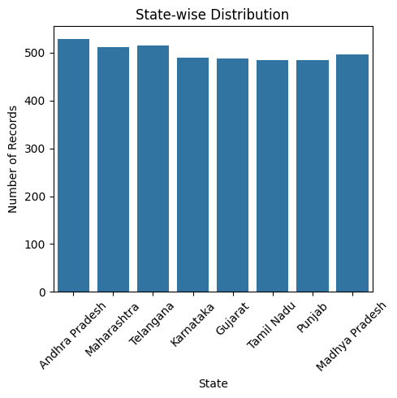

```python
plt.figure(figsize=(5, 5))

sns.countplot(data=agri_data, x='State')

plt.title('State-wise Distribution')
plt.xlabel('State')
plt.ylabel('Number of Records')
plt.xticks(rotation=45)

plt.tight_layout()
plt.show()
```

```python
print("District-wise Distribution:")
print(agri_data['District'].value_counts())
```

```
District-wise Distribution:
District
Ludhiana    427
Warangal    422
Nalgonda    415
Erode       403
Rajkot      401
Krishna     393
Indore      392
Guntur      390
Raichur     386
Nashik      371
Name: count, dtype: int64
```

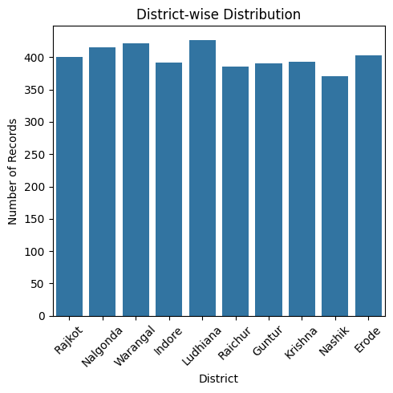

```python
plt.figure(figsize=(5, 5))

sns.countplot(data=agri_data, x='District')

plt.title('District-wise Distribution')
plt.xlabel('District')
plt.ylabel('Number of Records')
plt.xticks(rotation=45)

plt.tight_layout()
plt.show()
```

**Data-quality observation:**

- The dataset contains multiple district values across different states, indicating that State and District are not represented as a strict geographical hierarchy. Therefore, State and District were analyzed independently rather than treating District as a subset of State.

#### Key Insights:

- `State Distribution`: **Andhra Pradesh** has the **highest** number of records, while **Punjab** has the **lowest**. However, the difference between states is relatively small, indicating a **fairly balanced** state-wise representation.
- `District Distribution`: **Warangal** and **Ludhiana** have the **highest** number of records, whereas **Nashik** has the **lowest**. Overall, the district-wise distribution is **relatively balanced**.
- `Overall Observation`: No single state or district dominates the dataset, providing a reasonable representation for comparative analysis across these categories.

```python
print("Crop-wise Distribution:")
print(agri_data['Crop'].value_counts())

print("\nSeason-wise Distribution:")
print(agri_data['Season'].value_counts())

print("\nIrrigation Method Distribution:")
print(agri_data['Irrigation_Method'].value_counts())
```

```
Crop-wise Distribution:
Crop
Rice         690
Wheat        614
Maize        551
Cotton       508
Pulses       496
Groundnut    424
Chilli       412
Sugarcane    305
Name: count, dtype: int64

Season-wise Distribution:
Season
Kharif    1779
Rabi      1627
Zaid       594
Name: count, dtype: int64

Irrigation Method Distribution:
Irrigation_Method
Flood        1310
Rainfed      1041
Drip          915
Sprinkler     734
Name: count, dtype: int64
```

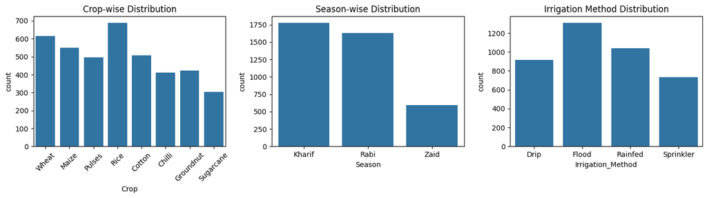

```python
fig, axes = plt.subplots(1, 3, figsize=(14, 4))

sns.countplot(data=agri_data, x='Crop', ax=axes[0])
axes[0].set_title('Crop-wise Distribution')
axes[0].tick_params(axis='x', rotation=45)

sns.countplot(data=agri_data, x='Season', ax=axes[1])
axes[1].set_title('Season-wise Distribution')

sns.countplot(data=agri_data, x='Irrigation_Method', ax=axes[2])
axes[2].set_title('Irrigation Method Distribution')

plt.tight_layout()
plt.show()
```

#### Key Insights:

- `Crop Distribution:` **Rice** has the highest number of records, while **Sugarcane** has the lowest representation. **Wheat and Maize** also have relatively high representation in the dataset.
- `Season Distribution:` **Kharif** has the highest number of observations, followed by **Rabi**. **Zaid** has significantly fewer records compared with the other two seasons.
- `Irrigation Method:` **Flood irrigation** is the most commonly used method, followed by **Rainfed and Drip**. **Sprinkler** irrigation has the lowest number of observations.
- `Overall Observation:` The dataset is more heavily represented by Rice, Kharif season, and Flood irrigation, while Sugarcane, Zaid season, and Sprinkler irrigation have comparatively fewer observations.

## 8. Seasonal Agricultural Performance:

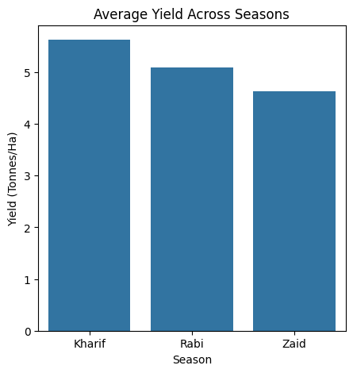

```python
plt.figure(figsize=(5, 5))

sns.barplot(data=agri_data, x="Season", y="Yield_Tonnes_Ha", errorbar=None)

plt.title("Average Yield Across Seasons")
plt.xlabel("Season")
plt.ylabel("Yield (Tonnes/Ha)")

plt.show()
```

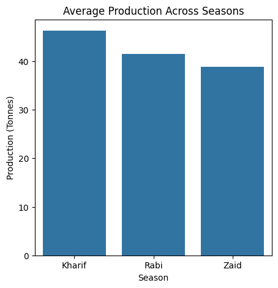

```python
plt.figure(figsize=(5, 5))

sns.barplot(data=agri_data, x="Season", y="Production_Tonnes", errorbar=None)

plt.title("Average Production Across Seasons")
plt.xlabel("Season")
plt.ylabel("Production (Tonnes)")

plt.show()
```

```python
# Overall Seasonal Performance Scorecard
season_summary = agri_data.groupby("Season").agg(
    Avg_Yield=("Yield_Tonnes_Ha", "mean"),
    Avg_Production=("Production_Tonnes", "mean"),
    Avg_Revenue=("Revenue_INR", "mean"),
    Avg_Profit=("Profit_INR", "mean"),
    Avg_Water_Efficiency=("Water_Efficiency_t_per_1000m3", "mean"),
    Avg_Disease_Risk=("Disease_Pest_Risk_pct", "mean")
).round(2)

print("Overall Seasonal Performance Scorecard :")
season_summary.T
```

```
Overall Seasonal Performance Scorecard :
```

| Season | Kharif | Rabi | Zaid |
| --- | --- | --- | --- |
| Avg_Yield | 5.63 | 5.09 | 4.63 |
| Avg_Production | 46.31 | 41.49 | 38.89 |
| Avg_Revenue | 710719.06 | 601526.05 | 519171.90 |
| Avg_Profit | 178914.65 | 87689.47 | -24804.82 |
| Avg_Water_Efficiency | 5.89 | 5.19 | 4.41 |
| Avg_Disease_Risk | 54.47 | 40.48 | 38.22 |

#### Key Insights:

- `Yield:` **Kharif** records the highest average yield at **5.63 tonnes/ha**, followed by Rabi at 5.09, while Zaid has the lowest at 4.63 tonnes/ha.
- `Production:` Average production follows a similar pattern, with **Kharif highest (46.31 tonnes)** and **Zaid lowest (38.89 tonnes)**.
- `Revenue:` **Kharif** generates the highest average revenue of about **₹7.11 lakh**, while **Zaid** has the lowest at about **₹5.19 lakh**.
- `Profit:` **Kharif** is the most profitable season, with an average profit of about **₹1.79 lakh**. Rabi averages about ₹0.88 lakh, while Zaid shows a negative average profit of about ₹24,805, indicating comparatively poor economic performance.
- `Water Efficiency:` **Kharif** has the highest average water efficiency (5.89), followed by Rabi (5.19) and Zaid (4.41).
- `Disease Risk:` Average disease risk is highest in **Kharif (54.47%)**, while Zaid has the lowest (38.22%).
- `Overall Observation:` **Kharif** shows the strongest overall agricultural performance across yield, production, revenue, profit, and water efficiency. **Zaid** performs weakest across most performance indicators despite having the lowest average disease risk.

## 9. Seasonal Environmental Analysis:

```python
# Environmental Conditions Across Seasons
environment_summary = agri_data.groupby("Season").agg(
    Rainfall=("Rainfall_mm", "mean"),
    Temperature=("Avg_Temperature_C", "mean"),
    Humidity=("Humidity_pct", "mean"),
    Sunlight=("Sunlight_Hours_Day", "mean"),
    Soil_Moisture=("Soil_Moisture_pct", "mean")
).round(2)

print("Environmental Conditions Across Seasons :")
environment_summary
```

```
Environmental Conditions Across Seasons :
```

| Season | Rainfall | Temperature | Humidity | Sunlight | Soil_Moisture |
| --- | --- | --- | --- | --- | --- |
| Kharif | 852.11 | 28.45 | 71.81 | 6.79 | 31.20 |
| Rabi | 435.93 | 23.49 | 57.89 | 7.59 | 24.05 |
| Zaid | 299.34 | 31.04 | 52.01 | 8.18 | 19.17 |

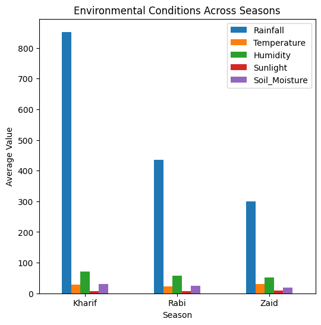

```python
environment_summary.plot(kind="bar", figsize=(6, 6))

plt.title("Environmental Conditions Across Seasons")
plt.ylabel("Average Value")
plt.xticks(rotation=0)

plt.show()
```

#### Key Insights:

- `Rainfall:` Kharif receives the highest average rainfall (**852.11 mm**), followed by Rabi (**435.93 mm**), while Zaid has the lowest (**299.34 mm**).
- `Temperature:` Zaid has the highest average temperature (**31.04°C**), while Rabi has the lowest (**23.49°C**).
- `Humidity:` Kharif has the highest average humidity (**71.81%**), followed by Rabi (**57.89%**) and Zaid (**52.01%**).
- `Sunlight:` Average sunlight increases from Kharif (**6.79 hours/day**) to Rabi (**7.59**) and is highest in Zaid (**8.18 hours/day**).
- `Soil Moisture:` Kharif has the highest average soil moisture (**31.20%**), while Zaid has the lowest (**19.17%**).
- `Overall Observation:` Kharif is characterized by **higher rainfall, humidity, and soil moisture**, whereas Zaid experiences **higher temperature and sunlight but lower rainfall and soil moisture**. These seasonal environmental differences may help explain the variations in agricultural performance observed earlier.

## 10. Seasonal Resource Usage:

```python
# Farming Inputs Across Seasons
resource_summary = agri_data.groupby("Season").agg(
    Fertilizer=("Fertilizer_kg_ha", "mean"),
    Pesticide=("Pesticide_Litre_ha", "mean"),
    Water_Used=("Water_Used_m3", "mean")
).round(2)

print("Farming Inputs Across Seasons :")
resource_summary
```

```
Farming Inputs Across Seasons :
```

| Season | Fertilizer | Pesticide | Water_Used |
| --- | --- | --- | --- |
| Kharif | 187.08 | 5.08 | 6102.20 |
| Rabi | 185.41 | 5.02 | 5846.99 |
| Zaid | 184.64 | 5.17 | 6419.89 |

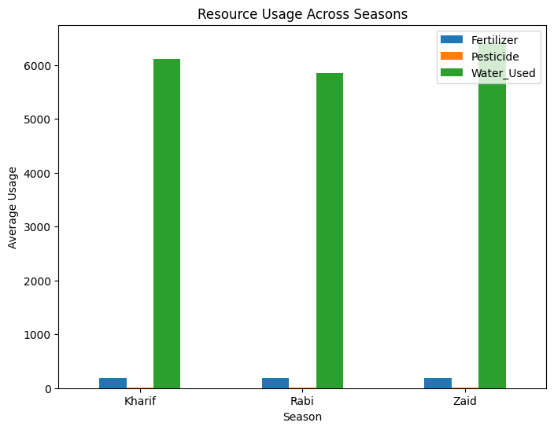

```python
resource_summary.plot(kind="bar", figsize=(8, 6))

plt.title("Resource Usage Across Seasons")
plt.ylabel("Average Usage")
plt.xticks(rotation=0)

plt.show()
```

```python
# Irrigation Practices Across Seasons
irrigation_percentage = pd.crosstab(
    agri_data["Season"],
    agri_data["Irrigation_Method"],
    normalize="index"
) * 100

print("Irrigation Practices (%) Across Seasons :")
irrigation_percentage.round(2)
```

```
Irrigation Practices (%) Across Seasons :
```

| Irrigation_Method Season | Drip | Flood | Rainfed | Sprinkler |
| --- | --- | --- | --- | --- |
| Kharif | 22.77 | 33.16 | 26.03 | 18.04 |
| Rabi | 22.74 | 32.33 | 26.92 | 18.01 |
| Zaid | 23.57 | 32.66 | 23.57 | 20.20 |

## 11. Soil and Agricultural Input Analysis:

```python
# Soil Conditions Across Seasons
soil_summary = agri_data.groupby("Season").agg(
    Soil_pH=("Soil_pH", "mean"),
    Soil_Moisture=("Soil_Moisture_pct", "mean"),
    Nitrogen=("Nitrogen_kg_ha", "mean"),
    Phosphorus=("Phosphorus_kg_ha", "mean"),
    Potassium=("Potassium_kg_ha", "mean")
).round(2)

print("Soil Conditions Across Seasons :")
soil_summary
```

```
Soil Conditions Across Seasons :
```

| Season | Soil_pH | Soil_Moisture | Nitrogen | Phosphorus | Potassium |
| --- | --- | --- | --- | --- | --- |
| Kharif | 6.73 | 31.20 | 120.02 | 58.10 | 105.30 |
| Rabi | 6.67 | 24.05 | 120.40 | 57.31 | 103.93 |
| Zaid | 6.69 | 19.17 | 120.53 | 58.13 | 105.42 |

```python
# Agricultural Input Across Seasons
input_summary = agri_data.groupby("Season").agg(
    Fertilizer=("Fertilizer_kg_ha", "mean"),
    Pesticide=("Pesticide_Litre_ha", "mean"),
    Seed_Quality=("Seed_Quality_Score", "mean"),
    Water_Used=("Water_Used_m3", "mean")
).round(2)

print("Agricultural Inputs Across Seasons :")
input_summary
```

```
Agricultural Inputs Across Seasons :
```

| Season | Fertilizer | Pesticide | Seed_Quality | Water_Used |
| --- | --- | --- | --- | --- |
| Kharif | 187.08 | 5.08 | 0.82 | 6102.20 |
| Rabi | 185.41 | 5.02 | 0.83 | 5846.99 |
| Zaid | 184.64 | 5.17 | 0.82 | 6419.89 |

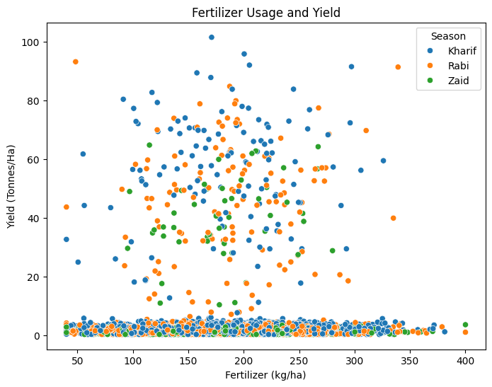

```python
# Fertilizer vs Yield
plt.figure(figsize=(8,6))

sns.scatterplot(data=agri_data, x="Fertilizer_kg_ha", y="Yield_Tonnes_Ha",
                hue="Season")

plt.title("Fertilizer Usage and Yield")
plt.xlabel("Fertilizer (kg/ha)")
plt.ylabel("Yield (Tonnes/Ha)")

plt.show()
```

#### Key Insights:

- `Soil pH:` Soil pH remains fairly stable across seasons, ranging from **6.67 to 6.73**, indicating only minor seasonal variation.
- `Soil Moisture:` Kharif has the highest average soil moisture (**31.20%**), while Zaid has the lowest (**19.17%**), showing a clear seasonal difference in soil water availability.
- `Nutrients:` Nitrogen, phosphorus, and potassium levels remain relatively similar across seasons, with only small variations in their average values.
- `Seed Quality:` Seed quality is almost consistent across seasons, with Rabi showing a slightly higher average score (**0.83**) compared with Kharif and Zaid (**0.82**).
- `Fertilizer and Yield:` The scatter plot shows **no clear strong linear relationship** between fertilizer usage and yield. Yield values are widely spread across different fertilizer levels, suggesting that other factors may also influence agricultural productivity.
- `Overall Observation:` Soil moisture shows the most noticeable seasonal variation, while soil pH, nutrient levels, seed quality, and fertilizer usage remain relatively stable. The fertilizer–yield relationship appears complex and requires further analysis with other environmental and farming factors.

## 12. Crop–Season Performance:

```python
# Crop performance in different seasons
crop_season = pd.pivot_table(
    agri_data,
    values="Yield_Tonnes_Ha",
    index="Crop",
    columns="Season",
    aggfunc="mean"
)

print("Crop Performance in Different Seasons :")
crop_season
```

```
Crop Performance in Different Seasons :
```

| Season Crop | Kharif | Rabi | Zaid |
| --- | --- | --- | --- |
| Chilli | 1.726594 | 1.459022 | 1.183749 |
| Cotton | 1.373022 | 1.193693 | 0.944560 |
| Groundnut | 1.481712 | 1.225648 | 1.037778 |
| Maize | 2.966410 | 2.616394 | 2.276190 |
| Pulses | 1.036063 | 0.872298 | 0.646429 |
| Rice | 2.706906 | 2.326805 | 1.900490 |
| Sugarcane | 53.459120 | 43.954495 | 38.423922 |
| Wheat | 2.251536 | 2.059075 | 1.748588 |

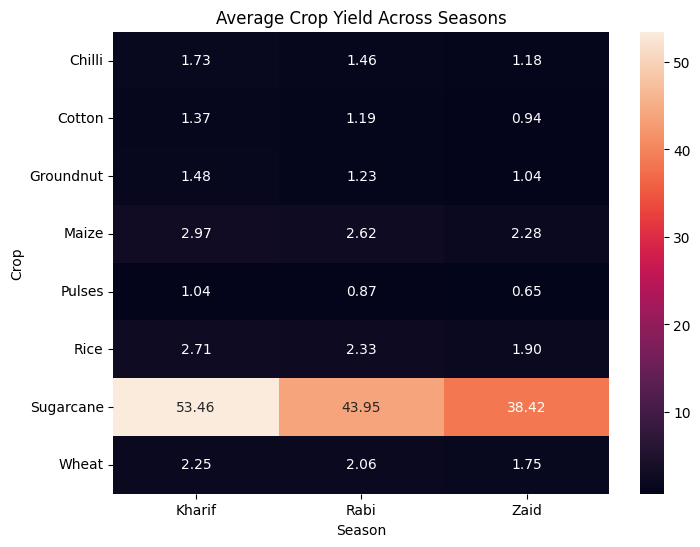

```python
plt.figure(figsize=(8, 6))

sns.heatmap(crop_season, annot=True, fmt=".2f")

plt.title("Average Crop Yield Across Seasons")

plt.show()
```

#### Key Insights:

- `Overall seasonal pattern:` All crops show a **decline in average yield from Kharif to Rabi and then Zaid**, indicating lower crop performance in Zaid.
- `Sugarcane:` Sugarcane has by far the **highest average yield** across all seasons, with **53.46 tonnes/ha in Kharif**, declining to **43.95 in Rabi** and **38.42 in Zaid**.
- `Other crops:` Among the remaining crops, **Maize and Rice** show relatively higher yields, while **Pulses and Cotton** have comparatively lower yields across seasons.
- `Kharif performance:` Kharif records the **highest yield for every crop**, suggesting generally more favorable conditions for crop productivity during this season.
- `Zaid performance:` Zaid has the **lowest yield for every crop**, showing a consistent seasonal reduction rather than the decline being limited to specific crops.
- `Overall observation:` The consistent Kharif > Rabi > Zaid pattern across all crops indicates that **season has a noticeable influence on crop yield**, with the extent of the difference varying by crop.

## 13. Seasonal Water Efficiency:

```python
# Water Summary Across Seasons
water_summary = agri_data.groupby("Season").agg(
    Water_Used=("Water_Used_m3", "mean"),
    Water_Efficiency=("Water_Efficiency_t_per_1000m3", "mean"),
    Yield=("Yield_Tonnes_Ha", "mean")
).round(2)

print("Water Summary Across Seasons :")
water_summary
```

```
Water Summary Across Seasons :
```

| Season | Water_Used | Water_Efficiency | Yield |
| --- | --- | --- | --- |
| Kharif | 6102.20 | 5.89 | 5.63 |
| Rabi | 5846.99 | 5.19 | 5.09 |
| Zaid | 6419.89 | 4.41 | 4.63 |

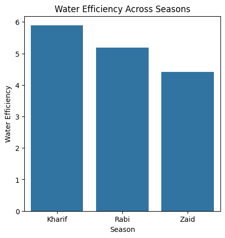

```python
plt.figure(figsize=(5, 5))

sns.barplot(data=agri_data, x="Season", y="Water_Efficiency_t_per_1000m3",
            errorbar=None)

plt.title("Water Efficiency Across Seasons")
plt.xlabel("Season")
plt.ylabel("Water Efficiency")

plt.show()
```

#### Key Insights:

- `Water Usage:` Zaid has the highest average water consumption (**6,419.89 m³**), while Rabi has the lowest (**5,846.99 m³**).
- `Water Efficiency:` Kharif shows the **highest water efficiency (5.89)**, followed by Rabi (5.19), while Zaid has the lowest (4.41).
- `Yield:` Kharif also has the **highest average yield (5.63 tonnes/ha)**, whereas Zaid has the lowest (4.63 tonnes/ha).
- `Overall Observation:` Kharif achieves the **highest water efficiency and yield with moderate water usage**, while Zaid uses the most water but has the **lowest water efficiency and yield**. This suggests that higher water usage does not necessarily result in better agricultural performance.

## 14. Disease Risk and Agricultural Performance:

```python
disease_summary = agri_data.groupby("Season")["Disease_Pest_Risk_pct"].mean().sort_values(ascending=False)

print("Disease Risk % in Different Seasons :")
disease_summary
```

```
Disease Risk % in Different Seasons :
```

```
Season
Kharif    54.467903
Rabi      40.482114
Zaid      38.216667
Name: Disease_Pest_Risk_pct, dtype: float64
```

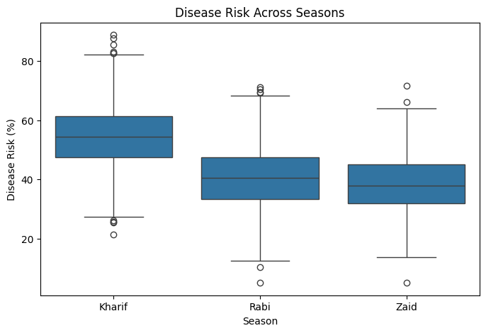

```python
plt.figure(figsize=(8, 5))

sns.boxplot(data=agri_data, x="Season", y="Disease_Pest_Risk_pct")

plt.title("Disease Risk Across Seasons")
plt.xlabel("Season")
plt.ylabel("Disease Risk (%)")

plt.show()
```

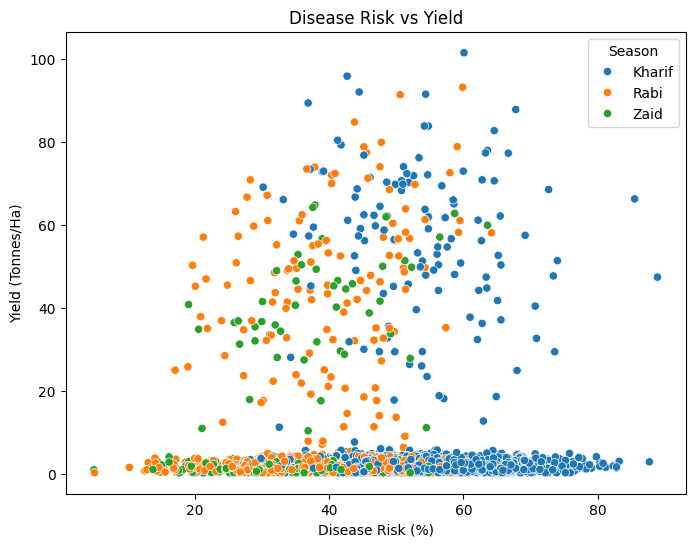

```python
# Disease Risk Relationship with Yield
plt.figure(figsize=(8, 6))

sns.scatterplot(data=agri_data, x="Disease_Pest_Risk_pct", y="Yield_Tonnes_Ha",
                hue="Season")

plt.title("Disease Risk vs Yield")
plt.xlabel("Disease Risk (%)")
plt.ylabel("Yield (Tonnes/Ha)")

plt.show()
```

## 15. Environmental Conditions relation with Agricultural Performance (Bivariate Analysis):

```python
# correlations with yield
environment_cols = [
    "Rainfall_mm",
    "Avg_Temperature_C",
    "Humidity_pct",
    "Sunlight_Hours_Day",
    "Soil_Moisture_pct"
]

agri_data[environment_cols + ["Yield_Tonnes_Ha"]].corr()["Yield_Tonnes_Ha"].sort_values(ascending=False)
```

```
Yield_Tonnes_Ha       1.000000
Rainfall_mm           0.026949
Humidity_pct          0.010837
Soil_Moisture_pct     0.010223
Avg_Temperature_C     0.009237
Sunlight_Hours_Day   -0.015593
Name: Yield_Tonnes_Ha, dtype: float64
```

### Rainfall vs Yield:

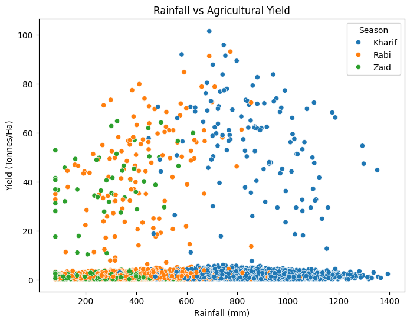

```python
plt.figure(figsize=(8, 6))

sns.scatterplot(data=agri_data, x="Rainfall_mm", y="Yield_Tonnes_Ha",
                hue="Season")

plt.title("Rainfall vs Agricultural Yield")
plt.xlabel("Rainfall (mm)")
plt.ylabel("Yield (Tonnes/Ha)")

plt.show()
```

### Temperature vs Yield:

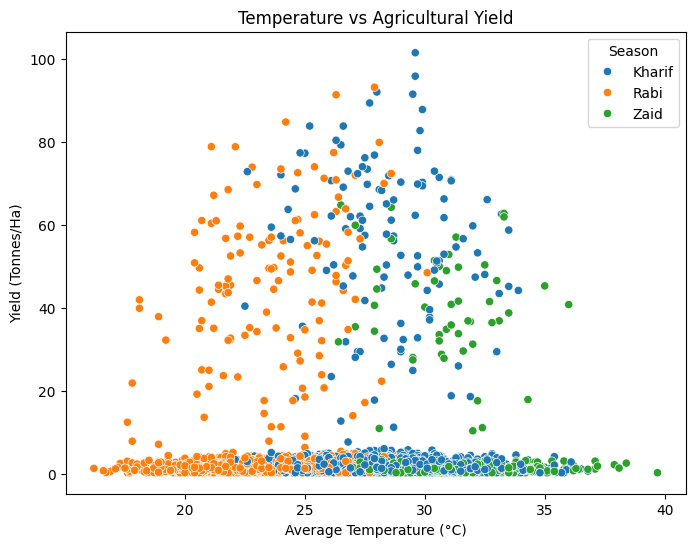

```python
plt.figure(figsize=(8, 6))

sns.scatterplot(data=agri_data, x="Avg_Temperature_C", y="Yield_Tonnes_Ha",
                hue="Season")

plt.title("Temperature vs Agricultural Yield")
plt.xlabel("Average Temperature (°C)")
plt.ylabel("Yield (Tonnes/Ha)")

plt.show()
```

### Water Usage vs Yield:

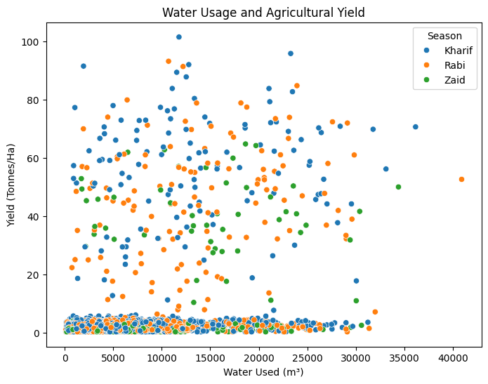

```python
plt.figure(figsize=(8,6))

sns.scatterplot(data=agri_data, x="Water_Used_m3", y="Yield_Tonnes_Ha",
                hue="Season")

plt.title("Water Usage and Agricultural Yield")
plt.xlabel("Water Used (m³)")
plt.ylabel("Yield (Tonnes/Ha)")

plt.show()
```

### Soil moisture vs Yield:

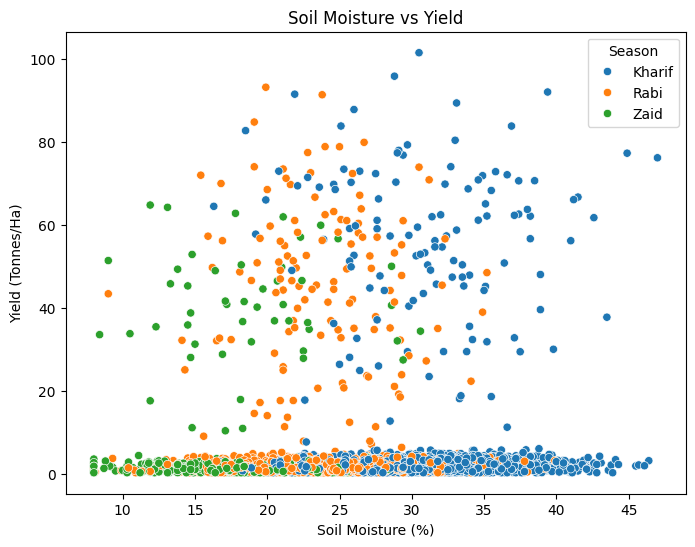

```python
plt.figure(figsize=(8, 6))

sns.scatterplot(data=agri_data, x="Soil_Moisture_pct", y="Yield_Tonnes_Ha",
                hue="Season")

plt.title("Soil Moisture vs Yield")
plt.xlabel("Soil Moisture (%)")
plt.ylabel("Yield (Tonnes/Ha)")

plt.show()
```

#### Key Insights:

- `Rainfall:` Rainfall has a **very weak positive correlation with yield (0.027)**, indicating almost no linear relationship between rainfall and agricultural yield in the dataset.
- `Temperature:` Temperature also shows an **almost negligible positive correlation (0.009)** with yield. The scatter plot does not show a clear upward or downward trend.
- `Humidity:` Humidity has a **very weak positive correlation (0.011)** with yield, suggesting that changes in humidity alone do not strongly explain yield variation.
- `Soil Moisture:` Soil moisture shows an **almost negligible positive correlation (0.010)** with yield. Although Kharif generally has higher soil moisture, the overall relationship with yield is not strong.
- `Sunlight:` Sunlight has a **very weak negative correlation (-0.016)** with yield, indicating that there is no meaningful linear relationship between sunlight duration and yield in the dataset.
- `Overall Observation:` All five environmental variables have correlation values very close to **zero**, suggesting that **none of them individually has a strong linear relationship with yield**. Agricultural yield is likely influenced by a combination of factors such as crop type, farming practices, soil nutrients, irrigation, and other conditions rather than a single environmental variable.

## 16. Regional Analysis:

### State-wise Performance:

```python
state_summary = agri_data.groupby("State").agg(
    Avg_Yield=("Yield_Tonnes_Ha", "mean"),
    Avg_Production=("Production_Tonnes", "mean"),
    Avg_Profit=("Profit_INR", "mean")
).sort_values("Avg_Yield", ascending=False)

print("State-wise Agricultural Performance :")
state_summary
```

```
State-wise Agricultural Performance :
```

| State | Avg_Yield | Avg_Production | Avg_Profit |
| --- | --- | --- | --- |
| Punjab | 6.121116 | 52.233099 | 136025.636364 |
| Gujarat | 5.760886 | 48.331988 | 117568.235656 |
| Karnataka | 5.751766 | 47.732720 | 119422.335378 |
| Telangana | 5.054321 | 39.254186 | 108829.616279 |
| Maharashtra | 5.013453 | 43.984043 | 135428.855469 |
| Madhya Pradesh | 4.984851 | 37.559517 | 86840.756539 |
| Tamil Nadu | 4.871460 | 40.840371 | 117744.748454 |
| Andhra Pradesh | 4.630964 | 36.913157 | 73453.527410 |

```python
# State × Season Analysis
state_season = pd.pivot_table(
    agri_data,
    values="Yield_Tonnes_Ha",
    index="State",
    columns="Season",
    aggfunc="mean"
)

print("Yield by State and Season :")
state_season
```

```
Yield by State and Season :
```

| Season State | Kharif | Rabi | Zaid |
| --- | --- | --- | --- |
| Andhra Pradesh | 5.683165 | 3.470442 | 4.445295 |
| Gujarat | 6.338416 | 5.696461 | 4.048209 |
| Karnataka | 6.448031 | 4.732307 | 6.623243 |
| Madhya Pradesh | 5.992789 | 3.746980 | 5.456009 |
| Maharashtra | 5.427516 | 5.501927 | 2.257771 |
| Punjab | 4.100633 | 8.609355 | 5.909610 |
| Tamil Nadu | 5.520534 | 4.492730 | 4.097746 |
| Telangana | 5.548589 | 4.817512 | 4.242469 |

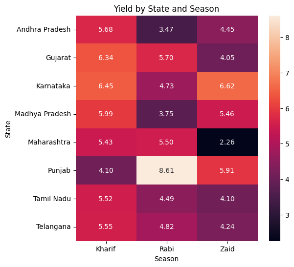

```python
plt.figure(figsize=(6, 6))

sns.heatmap(state_season, annot=True, fmt=".2f")

plt.title("Yield by State and Season")

plt.show()
```

### District-wise Performance:

```python
# District Performance
district_summary = agri_data.groupby("District").agg(
    Avg_Yield=("Yield_Tonnes_Ha", "mean"),
    Avg_Production=("Production_Tonnes", "mean"),
    Avg_Profit=("Profit_INR", "mean")
).sort_values("Avg_Yield", ascending=False)

print("District-wise Agricultural Performance :")
district_summary
```

```
District-wise Agricultural Performance :
```

| District | Avg_Yield | Avg_Production | Avg_Profit |
| --- | --- | --- | --- |
| Rajkot | 6.018600 | 54.831671 | 119463.276808 |
| Nalgonda | 5.807000 | 47.539566 | 131125.836145 |
| Ludhiana | 5.791039 | 45.164614 | 87590.831382 |
| Guntur | 5.603201 | 44.621667 | 116411.417949 |
| Warangal | 5.583886 | 46.270711 | 166449.962085 |
| Raichur | 4.943342 | 39.281347 | 125172.699482 |
| Indore | 4.883240 | 38.555638 | 90421.341837 |
| Nashik | 4.862074 | 36.736739 | 94910.172507 |
| Krishna | 4.844021 | 40.524122 | 78240.903308 |
| Erode | 4.177908 | 37.773499 | 102079.565757 |

```python
# District × Season Analysis
district_season = pd.pivot_table(
    agri_data,
    values="Yield_Tonnes_Ha",
    index="District",
    columns="Season",
    aggfunc="mean"
)

print("Yield by District and Season :")
district_season
```

```
Yield by District and Season :
```

| Season District | Kharif | Rabi | Zaid |
| --- | --- | --- | --- |
| Erode | 4.309154 | 4.440259 | 3.265123 |
| Guntur | 6.024056 | 4.885875 | 6.199641 |
| Indore | 6.120820 | 3.535779 | 4.538364 |
| Krishna | 5.507760 | 4.710251 | 2.879414 |
| Ludhiana | 6.375708 | 5.520124 | 5.075821 |
| Nalgonda | 6.582151 | 4.458106 | 7.404394 |
| Nashik | 5.524969 | 4.697447 | 3.390339 |
| Raichur | 4.095897 | 6.656532 | 3.287705 |
| Rajkot | 6.652477 | 5.963889 | 4.326786 |
| Warangal | 5.269356 | 5.892620 | 5.808266 |

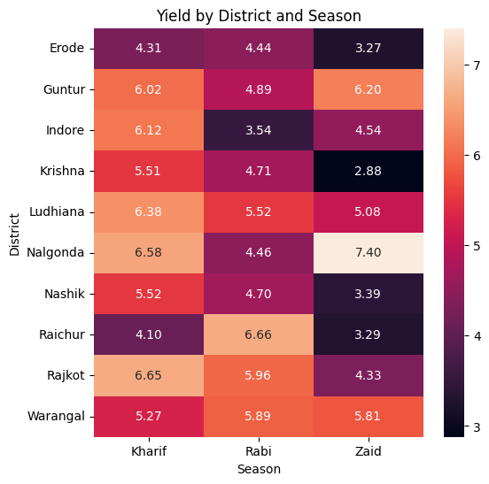

```python
plt.figure(figsize=(6, 6))

sns.heatmap(district_season, annot=True, fmt=".2f")

plt.title("Yield by District and Season")

plt.show()
```

## 17. Economic Performance:

### Revenue, Cost and Profit:

```python
economic_summary = agri_data.groupby("Season").agg(
    Market_Price=("Market_Price_INR_Tonne", "mean"),
    Total_Cost=("Total_Cost_INR", "mean"),
    Revenue=("Revenue_INR", "mean"),
    Profit=("Profit_INR", "mean")
).round(2)

print("Season-wise Average Economic Summary :")
economic_summary
```

```
Season-wise Average Economic Summary :
```

| Season | Market_Price | Total_Cost | Revenue | Profit |
| --- | --- | --- | --- | --- |
| Kharif | 44850.91 | 531804.41 | 710719.06 | 178914.65 |
| Rabi | 44747.97 | 513836.58 | 601526.05 | 87689.47 |
| Zaid | 44212.03 | 543976.73 | 519171.90 | -24804.82 |

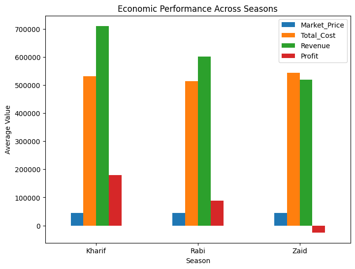

```python
economic_summary.plot(kind="bar", figsize=(8,6))

plt.title("Economic Performance Across Seasons")
plt.xlabel("Season")
plt.ylabel("Average Value")
plt.xticks(rotation=0)

plt.show()
```

### Profit Margin:

```python
profit_margin = (agri_data.groupby("Season")
    .agg(Revenue=("Revenue_INR", "sum"),Profit=("Profit_INR", "sum"))
)

profit_margin["Profit_Margin_%"] = (profit_margin["Profit"] /
                                    profit_margin["Revenue"]) * 100

profit_margin.round(2)
```

| Season | Revenue | Profit | Profit_Margin_% |
| --- | --- | --- | --- |
| Kharif | 1264369200 | 318289158 | 25.17 |
| Rabi | 978682881 | 142670768 | 14.58 |
| Zaid | 308388111 | -14734066 | -4.78 |

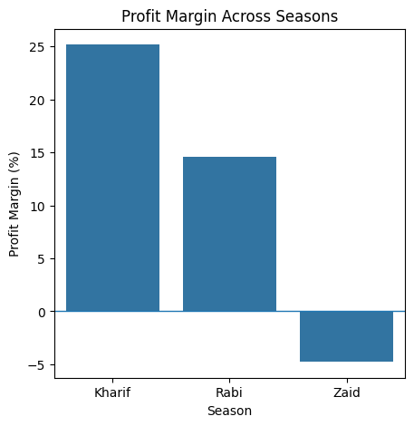

```python
plt.figure(figsize=(5,5))

sns.barplot(x=profit_margin.index, y=profit_margin["Profit_Margin_%"])

plt.axhline(0, linewidth=1)

plt.title("Profit Margin Across Seasons")
plt.xlabel("Season")
plt.ylabel("Profit Margin (%)")

plt.show()
```

#### Key Insights:

- `Market Price:` Average market prices are almost the same across seasons, with only minor variation. Kharif has the highest average price at **₹44,850.91 per tonne**, while Zaid has the lowest at **₹44,212.03**.
- `Total Cost:` Zaid has the **highest average cost (₹5.44 lakh)**, slightly higher than Kharif and Rabi.
- `Revenue:` Kharif generates the **highest average revenue (₹7.11 lakh)**, followed by Rabi (₹6.02 lakh), while Zaid has the lowest (₹5.19 lakh).
- `Profit:` Kharif has the **highest average profit (₹1.79 lakh)**, Rabi earns about **₹0.88 lakh**, while Zaid records an **average loss of ₹24,805**.
- `Profit Margin:` The season-level profit margin confirms that **Kharif is the most profitable (25.17%)**, followed by Rabi (14.58%), while Zaid has a **negative margin (-4.78%)**.
- `Overall Observation:` Kharif demonstrates the **strongest economic performance**, combining higher revenue, profit, and profit margin. Zaid faces the weakest performance, with higher costs but lower revenue, resulting in an overall loss.

## 18. Seasonal Multi-Factor Comparison:

```python
multivariate_summary = agri_data.groupby("Season").agg(
    Rainfall=("Rainfall_mm", "mean"),
    Temperature=("Avg_Temperature_C", "mean"),
    Soil_Moisture=("Soil_Moisture_pct", "mean"),
    Fertilizer=("Fertilizer_kg_ha", "mean"),
    Water_Used=("Water_Used_m3", "mean"),
    Yield=("Yield_Tonnes_Ha", "mean"),
    Profit=("Profit_INR", "mean")
).round(2)

multivariate_summary
```

| Season | Rainfall | Temperature | Soil_Moisture | Fertilizer | Water_Used | Yield | Profit |
| --- | --- | --- | --- | --- | --- | --- | --- |
| Kharif | 852.11 | 28.45 | 31.20 | 187.08 | 6102.20 | 5.63 | 178914.65 |
| Rabi | 435.93 | 23.49 | 24.05 | 185.41 | 5846.99 | 5.09 | 87689.47 |
| Zaid | 299.34 | 31.04 | 19.17 | 184.64 | 6419.89 | 4.63 | -24804.82 |

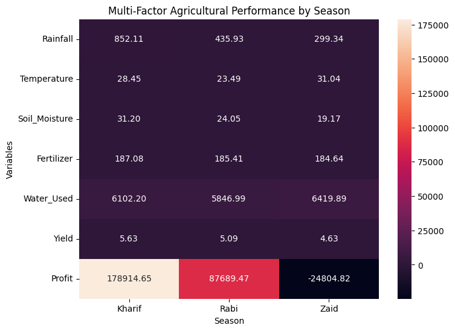

```python
plt.figure(figsize=(8,6))

sns.heatmap(multivariate_summary.T, annot=True, fmt=".2f")

plt.title("Multi-Factor Agricultural Performance by Season")
plt.xlabel("Season")
plt.ylabel("Variables")

plt.show()
```

#### Key Insights:

- `Kharif:` Shows the strongest overall performance, with the highest rainfall (**852.11 mm**), soil moisture (**31.20%**), yield (**5.63 tonnes/ha**), and profit (**₹1.79 lakh**).
- `Rabi:` Shows moderate performance across most indicators, with **5.09 tonnes/ha yield** and **₹87,689 average profit**. It also has the lowest water usage (**5,846.99 m³**).
- `Zaid:` Has the **lowest rainfall (299.34 mm), soil moisture (19.17%), yield (4.63 tonnes/ha), and average profit (-₹24,805)**, while also having the highest water usage (**6,419.89 m³**).
- `Resource usage:` Fertilizer usage remains almost unchanged across seasons, while water usage varies more, with Zaid requiring the most water.
- `Overall Observation:` **Kharif demonstrates the strongest combination of environmental conditions, yield, and profitability**, whereas Zaid shows lower agricultural performance despite higher water usage. This suggests that seasonal conditions and resource efficiency together play an important role in overall agricultural performance.

## 19. Correlation Analysis:

```python
numeric_data = agri_data.select_dtypes(include=np.number)

correlation_matrix = numeric_data.corr()
```

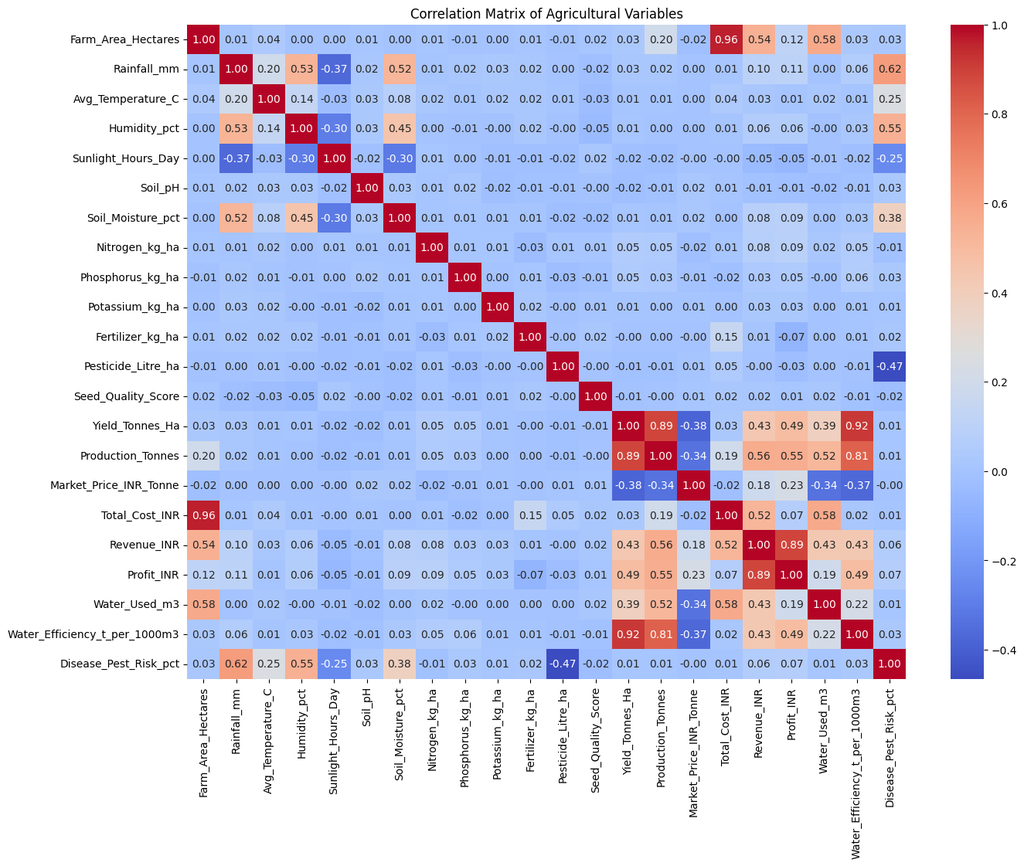

```python
plt.figure(figsize=(15,11))

sns.heatmap(
    correlation_matrix,
    annot=True,
    fmt=".2f",
    cmap="coolwarm"
)

plt.title("Correlation Matrix of Agricultural Variables")

plt.show()
```

#### Key Insights:

- `Yield and Production:` Yield has a **strong positive correlation with Production (0.89)**, indicating that higher yield is closely associated with higher total production.
- `Yield and Water Efficiency:` Yield shows a **very strong positive correlation with Water Efficiency (0.92)**, making water efficiency one of the strongest variables associated with yield.
- `Yield and Other Factors:` Yield has only **weak correlations with rainfall (0.03), temperature (0.01), humidity (0.01), and soil moisture (0.01)**, suggesting that these variables do not show a strong linear relationship with yield in the dataset.
- `Farm Area and Cost:` Farm area has a **very strong positive correlation with total cost (0.96)**, indicating that larger farms generally involve higher total costs.
- `Farm Area and Water Usage:` Farm area also has a **moderate positive correlation with water usage (0.58)**, suggesting that larger farms tend to require more water.
- `Economic Variables:` Revenue and profit show a **strong positive correlation (0.89)**, indicating that higher revenue is closely associated with higher profit. Production also has a strong relationship with revenue (**0.56**).
- `Disease Risk:` Disease risk has a **moderate negative correlation with pesticide usage (-0.47)** and positive relationships with rainfall (**0.62**) and humidity (**0.55**). These are associations in the dataset and do not by themselves establish causation.
- `Overall Observation:` The strongest relationships are mainly among **production, yield, water efficiency, farm size, and economic variables**, while individual environmental factors show very weak direct linear relationships with yield.

### Variables Most Related to Yield:

```python
yield_correlation = correlation_matrix["Yield_Tonnes_Ha"].sort_values(
    ascending=False
)

yield_correlation
```

```
Yield_Tonnes_Ha                  1.000000
Water_Efficiency_t_per_1000m3    0.915738
Production_Tonnes                0.885713
Profit_INR                       0.489655
Revenue_INR                      0.433389
Water_Used_m3                    0.387414
Nitrogen_kg_ha                   0.053418
Phosphorus_kg_ha                 0.046833
Total_Cost_INR                   0.031097
Farm_Area_Hectares               0.030731
Rainfall_mm                      0.026949
Disease_Pest_Risk_pct            0.012654
Humidity_pct                     0.010837
Soil_Moisture_pct                0.010223
Avg_Temperature_C                0.009237
Potassium_kg_ha                  0.005225
Fertilizer_kg_ha                -0.000343
Seed_Quality_Score              -0.007056
Pesticide_Litre_ha              -0.008276
Sunlight_Hours_Day              -0.015593
Soil_pH                         -0.021656
Market_Price_INR_Tonne          -0.384170
Name: Yield_Tonnes_Ha, dtype: float64
```

## 20. Outlier Analysis:

### Yield Outliers:

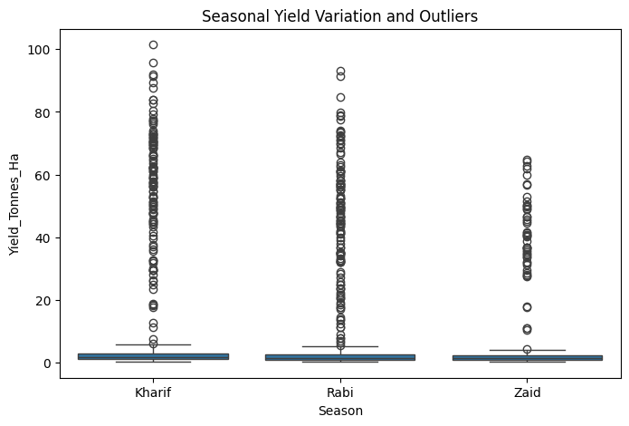

```python
plt.figure(figsize=(8, 5))

sns.boxplot(data=agri_data, x="Season", y="Yield_Tonnes_Ha")

plt.title("Seasonal Yield Variation and Outliers")

plt.show()
```

```python
Q1 = agri_data["Yield_Tonnes_Ha"].quantile(0.25)
Q3 = agri_data["Yield_Tonnes_Ha"].quantile(0.75)

IQR = Q3 - Q1

lower = Q1 - 1.5 * IQR
upper = Q3 + 1.5 * IQR

yield_outliers = agri_data[
    (agri_data["Yield_Tonnes_Ha"] < lower) |
    (agri_data["Yield_Tonnes_Ha"] > upper)
]

print("Number of yield outliers:", len(yield_outliers))
```

```
Number of yield outliers: 304
```

#### Key Insights:

```python
# Crops are responsible for the outliers
yield_outliers["Crop"].value_counts()
```

```
Crop
Sugarcane    295
Maize          7
Rice           2
Name: count, dtype: int64
```

```python
# Outliers distribution by Season
yield_outliers["Season"].value_counts()
```

```
Season
Kharif    129
Rabi      126
Zaid       49
Name: count, dtype: int64
```

```python
# Outliers distribution by State
yield_outliers["State"].value_counts()
```

```
State
Punjab            48
Karnataka         44
Gujarat           41
Maharashtra       38
Telangana         36
Madhya Pradesh    35
Andhra Pradesh    31
Tamil Nadu        31
Name: count, dtype: int64
```

```python
# Average Yield per Crop
agri_data.groupby("Crop")["Yield_Tonnes_Ha"].mean().sort_values(ascending=False)
```

```
Crop
Sugarcane    46.925049
Maize         2.713176
Rice          2.436758
Wheat         2.107621
Chilli        1.536409
Groundnut     1.318279
Cotton        1.224471
Pulses        0.917032
Name: Yield_Tonnes_Ha, dtype: float64
```

```python
# Crop-wise Yield Statistics
agri_data.groupby("Crop")["Yield_Tonnes_Ha"].agg(
    ["count", "mean", "median", "min", "max"]
).sort_values("mean", ascending=False)
```

| Crop | count | mean | median | min | max |
| --- | --- | --- | --- | --- | --- |
| Sugarcane | 305 | 46.925049 | 48.030 | 1.390000 | 101.44 |
| Maize | 551 | 2.713176 | 2.850 | 0.300000 | 6.08 |
| Rice | 690 | 2.436758 | 2.460 | 0.300000 | 5.70 |
| Wheat | 614 | 2.107621 | 2.215 | 0.300000 | 4.56 |
| Chilli | 412 | 1.536409 | 1.555 | 0.300000 | 3.90 |
| Groundnut | 424 | 1.318279 | 1.400 | 0.300000 | 3.02 |
| Cotton | 508 | 1.224471 | 1.240 | 0.299539 | 2.90 |
| Pulses | 496 | 0.917032 | 0.940 | 0.298592 | 2.09 |

#### Outliers Analysis Insights:

- **Sugarcane** accounts for **295 of the 304** detected outliers, which is about **97%** of all outliers.
- Sugarcane has an average yield of **46.93 tonnes/ha**, while the other crops have average yields mostly between **0.92 and 2.71 tonnes/ha**.
- Sugarcane's maximum yield is **101.44 tonnes/ha**, which is much higher in scale than the other crops.
- This strongly suggests that the global IQR method is flagging Sugarcane values mainly because **different crops have very different natural yield ranges.**
- The initial IQR analysis identified 304 potential yield outliers, of which 295 were from Sugarcane. Since crop yields vary considerably in scale, the global IQR method may classify naturally high-yielding Sugarcane observations as outliers.

### Final Seasonal Scorecard:

```python
final_summary = agri_data.groupby("Season").agg(
    Avg_Yield=("Yield_Tonnes_Ha", "mean"),
    Avg_Production=("Production_Tonnes", "mean"),
    Avg_Revenue=("Revenue_INR", "mean"),
    Avg_Profit=("Profit_INR", "mean"),
    Avg_Water_Usage=("Water_Used_m3", "mean"),
    Avg_Water_Efficiency=("Water_Efficiency_t_per_1000m3", "mean"),
    Avg_Disease_Risk=("Disease_Pest_Risk_pct", "mean")
).round(2)

print("Seasonal Scorecard :")
final_summary.T
```

```
Seasonal Scorecard :
```

| Season | Kharif | Rabi | Zaid |
| --- | --- | --- | --- |
| Avg_Yield | 5.63 | 5.09 | 4.63 |
| Avg_Production | 46.31 | 41.49 | 38.89 |
| Avg_Revenue | 710719.06 | 601526.05 | 519171.90 |
| Avg_Profit | 178914.65 | 87689.47 | -24804.82 |
| Avg_Water_Usage | 6102.20 | 5846.99 | 6419.89 |
| Avg_Water_Efficiency | 5.89 | 5.19 | 4.41 |
| Avg_Disease_Risk | 54.47 | 40.48 | 38.22 |

## 21. Key Findings:

#### `1. Seasonal Performance`

Kharif was the best-performing season overall, with the highest average yield (**5.63 tonnes/ha**), production (**46.31 tonnes**), revenue (**₹7.11 lakh**), profit (**₹1.79 lakh**), and water efficiency (**5.89**).

#### `2. Zaid Season Performance`

Zaid showed the weakest overall performance, with the lowest average yield (**4.63 tonnes/ha**), production (**38.89 tonnes**), revenue (**₹5.19 lakh**), and water efficiency (**4.41**), along with an average loss of about **₹24,805**.

#### `3. Seasonal Environmental Conditions`

Kharif had the highest rainfall (**852.11 mm**), humidity (**71.81%**), and soil moisture (**31.20%**), while Zaid had the highest temperature (**31.04°C**) and sunlight (**8.18 hours/day**).

#### `4. Water Usage and Efficiency`

Zaid used the highest average water (**6,419.89 m³**) but recorded the lowest water efficiency (**4.41**) and yield (**4.63 tonnes/ha**). This shows that higher water usage did not necessarily result in better agricultural performance.

#### `5. Crop-wise Performance`

Sugarcane had a substantially higher yield than the other crops, while the crops generally followed a **Kharif > Rabi > Zaid** yield pattern.

#### `6. Regional Performance`

Punjab had the highest overall state-level yield (**6.12 tonnes/ha**), while Andhra Pradesh had the lowest (**4.63 tonnes/ha**). However, the highest-performing state varied across seasons.

#### `7. Economic Performance`

Kharif recorded the highest profit margin (**25.17%**), followed by Rabi (**14.58%**), while Zaid recorded a negative profit margin (**-4.78%**).

#### `8. Environmental Factors and Yield`

Rainfall, temperature, humidity, and soil moisture showed **very weak linear correlations with yield**, indicating that no single environmental factor strongly explains yield variation in the dataset.

#### `9. Yield and Water Efficiency`

Yield showed strong positive correlations with **Production (0.89)** and **Water Efficiency (0.92)**, indicating strong associations between these measures and agricultural performance.

#### `10. Disease Risk`

Kharif had the highest average disease risk (**54.47%**) and Zaid the lowest (**38.22%**). However, Kharif still achieved the highest yield and profit, indicating that disease risk alone does not determine agricultural performance.

#### `11. Yield Outlier Analysis`

The initial IQR method identified **304 potential outliers**, of which 295 were from Sugarcane. This suggests most initial outliers were tied to Sugarcane's naturally higher yield range rather than clear data errors.

#### `12. Overall Agricultural Insight`

Overall, agricultural performance varies considerably across **Seasons, Crops, and Regions**. Kharif emerged as the strongest-performing season, while Zaid showed lower productivity and negative profitability. Effective seasonal planning should therefore consider **crop selection, environmental conditions, resource efficiency, regional variation, and economic performance together**.

## 22. Evidence-Based Recommendations:

#### 1. Prioritize Kharif for High Performance:

Given Kharif's highest yield, production, profit, and water efficiency, agricultural planning can prioritize suitable crops and farming activities during Kharif where conditions permit.

#### 2. Improve Zaid Water Efficiency:

Zaid records the **highest water usage but lowest water efficiency and yield**. Water management and irrigation practices should therefore be reviewed to improve productivity per unit of water.

#### 3. Focus on Zaid Cost Management:

Zaid records a **negative profit margin (-4.78%)**. Reducing unnecessary production costs and improving revenue generation should be a priority when planning Zaid-season activities.

#### 4. Use Crop-Specific Seasonal Planning:

Crop yields vary across seasons, with **Sugarcane performing at a much higher yield level** than the other crops. Crop selection and seasonal planning should therefore consider crop-specific performance rather than applying the same strategy to all crops.

#### 5. Adopt Region-Specific Planning:

State and district performance varies across seasons, with different regions emerging as top performers in different seasons. Agricultural strategies should therefore be tailored to **regional and seasonal conditions** rather than using a single approach across all locations.

#### 6. Improve Water-Focused Decision Making:

Because yield has a **strong positive association with water efficiency (0.92)**, improving efficient use of water should be an important planning focus rather than simply increasing total water consumption.

#### 7. Consider Multiple Factors in Yield Planning:

Environmental variables such as rainfall, temperature, humidity, and soil moisture showed **very weak individual linear relationships with yield**. Therefore, seasonal planning should consider environmental, crop, resource, and farming factors together rather than relying on a single environmental indicator.

## 23. Limitations:

- **Dataset Scope:** The analysis is limited to the variables and observations available in the given dataset.
- **State–District Inconsistency:** State and District values are not consistently matched, so they were analyzed independently.
- **Correlation Limitation:** Correlation shows relationships between variables but does not prove cause-and-effect relationships.
- **Limited Environmental Factors:** The available environmental variables alone may not fully explain variations in agricultural yield.
- **Outlier Sensitivity:** Outlier results can vary depending on the statistical method used.
- **Economic Factors:** The economic analysis depends on the revenue, cost, price, and profit information provided in the dataset and may not capture all real-world market factors.

## 24. Final Conclusion:

The analysis shows that **agricultural performance varies significantly across seasons, crops, and regions**. Among the seasons, **Kharif emerged as the strongest overall performer**, with the highest yield, production, revenue, profit, and water efficiency, while **Zaid showed comparatively lower productivity and negative profitability**.

The analysis also found that **crop and regional performance varies across seasons**, indicating that a single agricultural strategy may not be suitable for all conditions. Water efficiency showed a strong association with yield, whereas individual environmental factors such as rainfall, temperature, humidity, and soil moisture showed very weak linear relationships with yield.

Overall, the findings highlight the importance of **season-specific crop selection, efficient resource management, regional planning, and economic evaluation** for improving agricultural performance. The results provide a data-driven basis for better seasonal agricultural planning using the available dataset.